# Cluster Report: GoiEner POST, 20 clusters

Universidad de Deusto (carlos.quesada@deusto.es)

2022-02-21 14:49:52

#### List of abbreviations

##### Sets of features

- **sAggrDRM**: seasonal aggregates v2.0 (day-referenced mean)
- **sAggrP6**: seasonal aggregates v3.0 (6-period time division)

##### Datasets

- **goi**: GoiEner (including Megara and La Corriente) [ES]

##### Clustering methods

- **som**: self-organizing maps

## sAggrDRM > goi > som

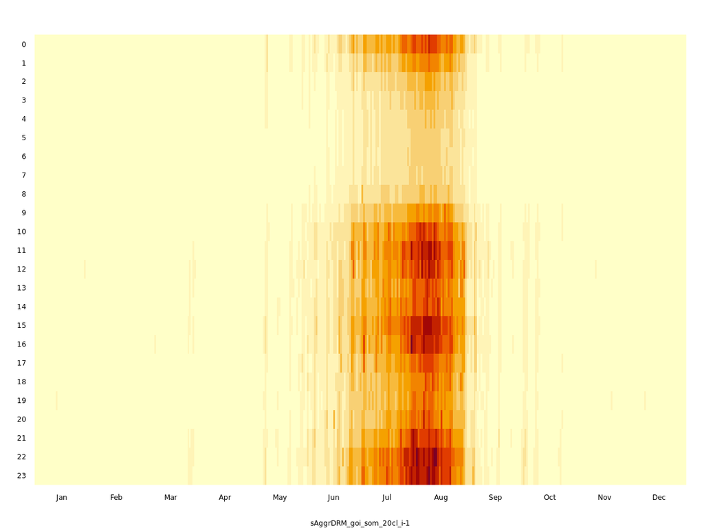

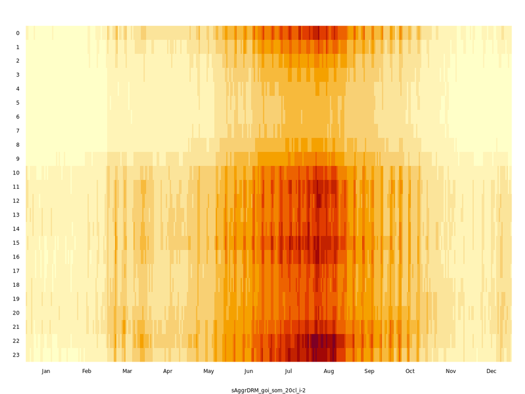

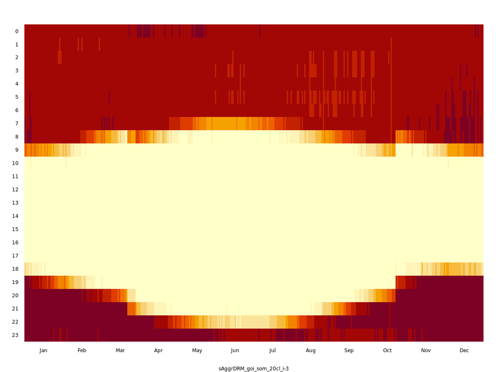

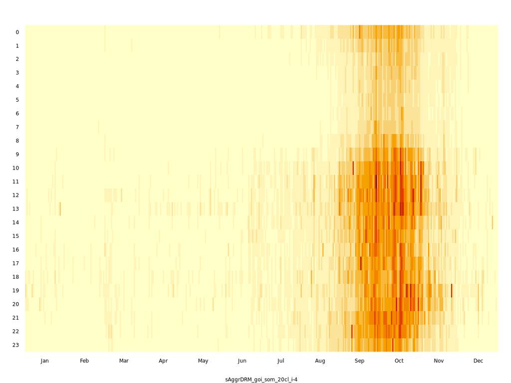

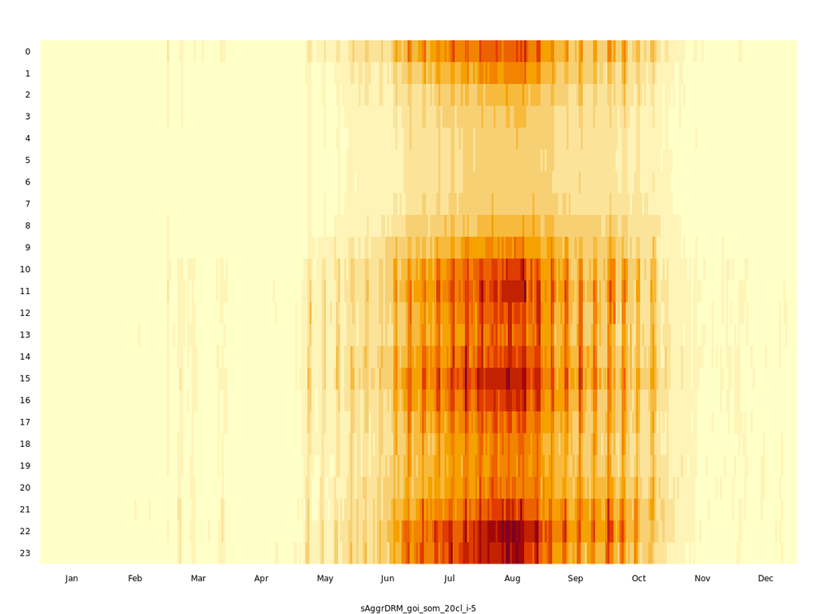

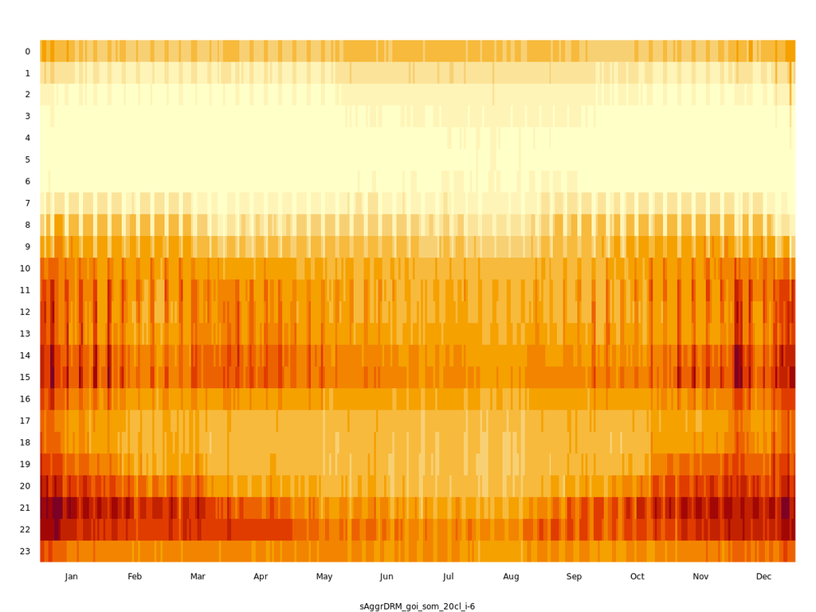

sAggrDRM > goi > som > #1

180 TS (1.2%)

sAggrDRM > goi > som > #2

659 TS (4.3%)

sAggrDRM > goi > som > #3

345 TS (2.3%)

sAggrDRM > goi > som > #4

86 TS (0.6%)

sAggrDRM > goi > som > #5

220 TS (1.4%)

sAggrDRM > goi > som > #6

2272 TS (14.9%)

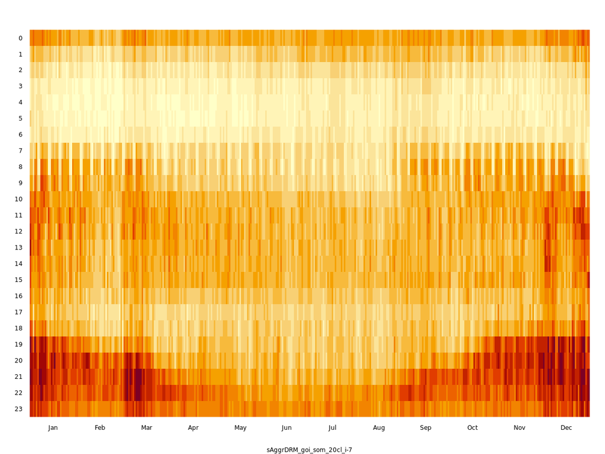

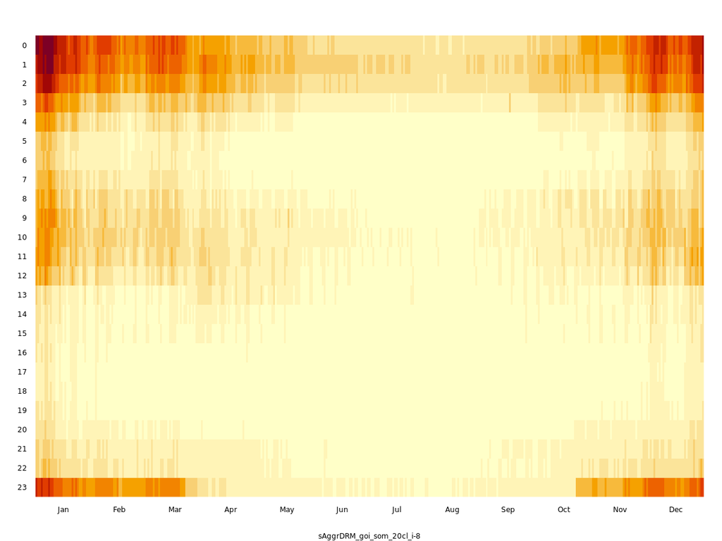

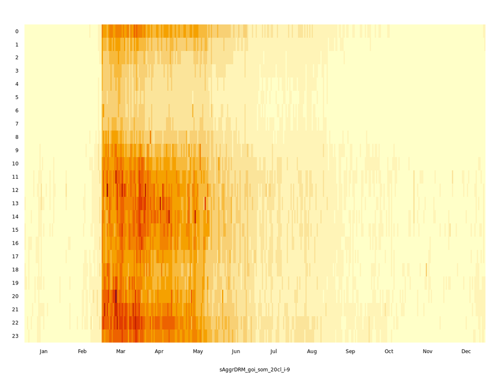

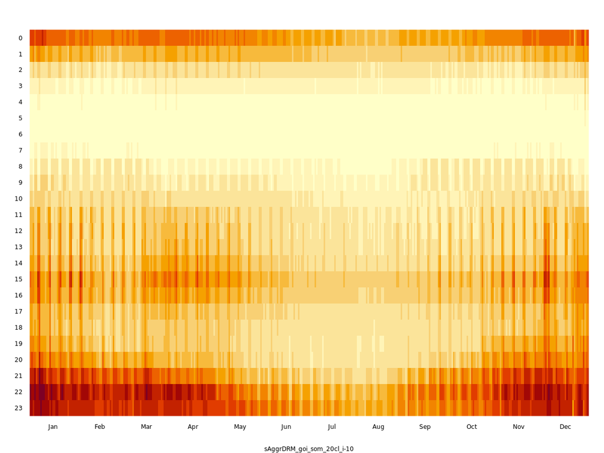

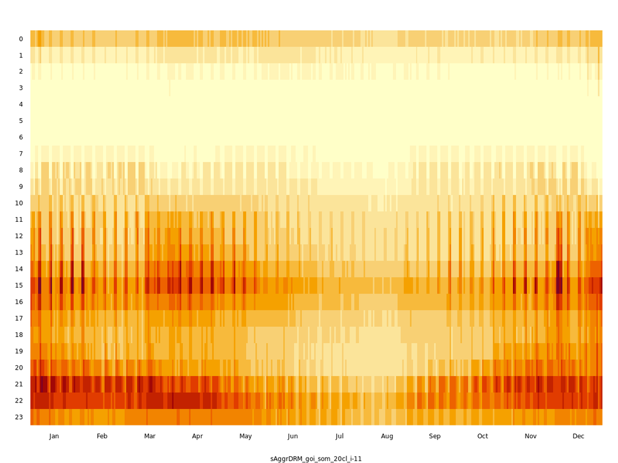

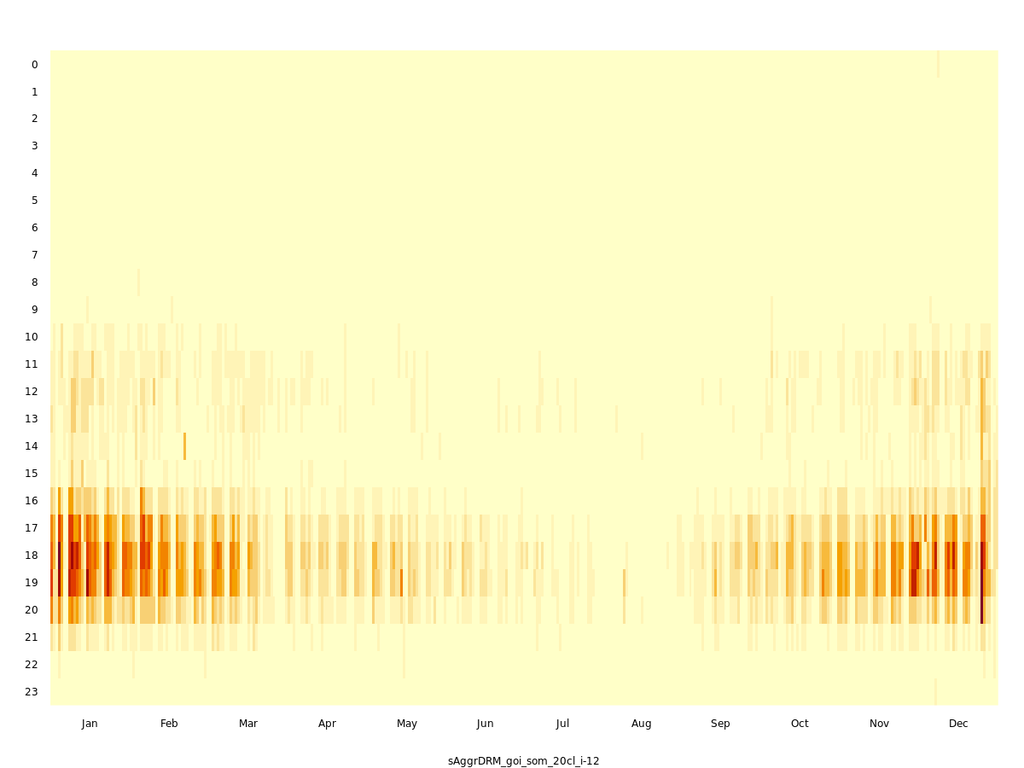

sAggrDRM > goi > som > #7

1139 TS (7.5%)

sAggrDRM > goi > som > #8

133 TS (0.9%)

sAggrDRM > goi > som > #9

144 TS (0.9%)

sAggrDRM > goi > som > #10

1402 TS (9.2%)

sAggrDRM > goi > som > #11

1825 TS (11.9%)

sAggrDRM > goi > som > #12

78 TS (0.5%)

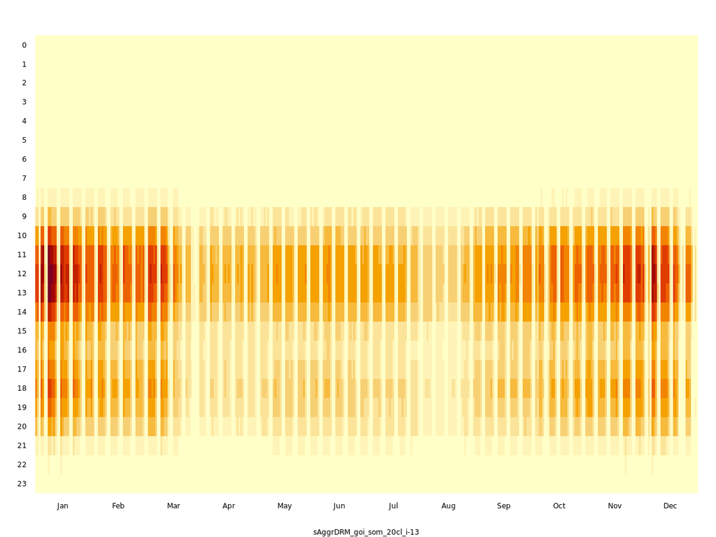

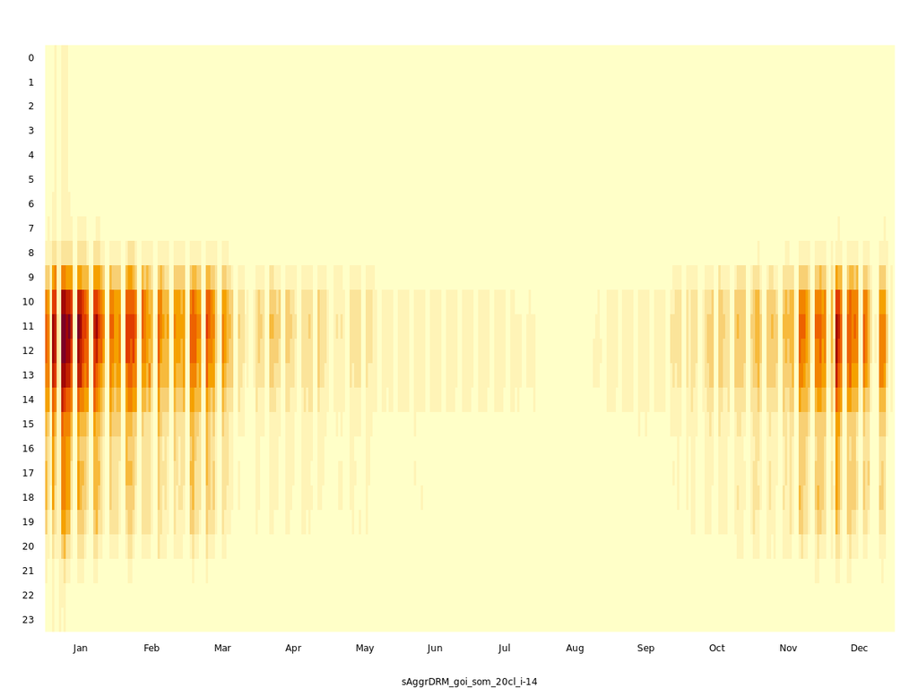

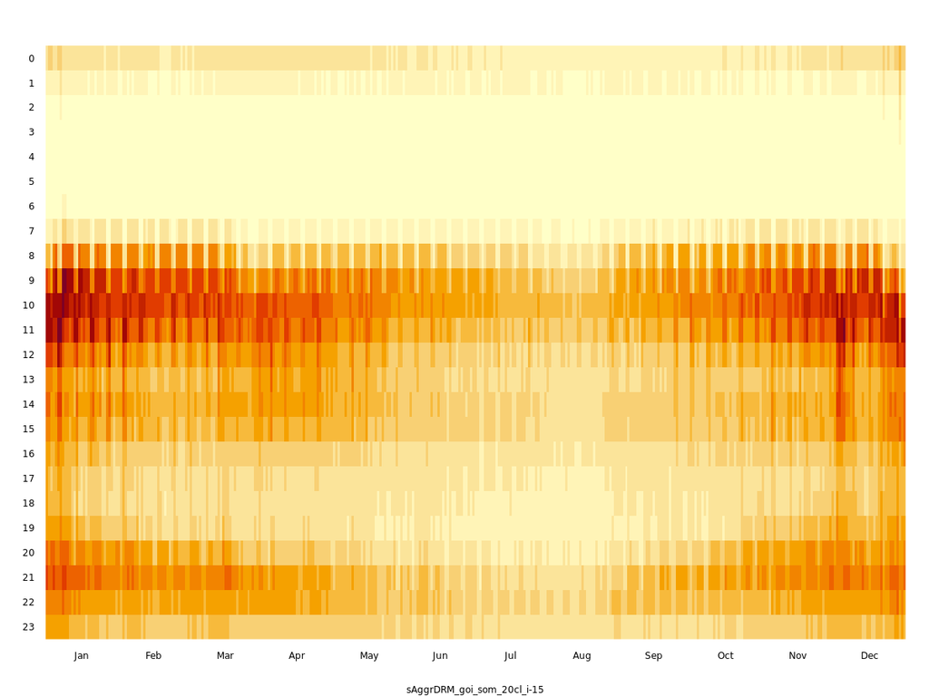

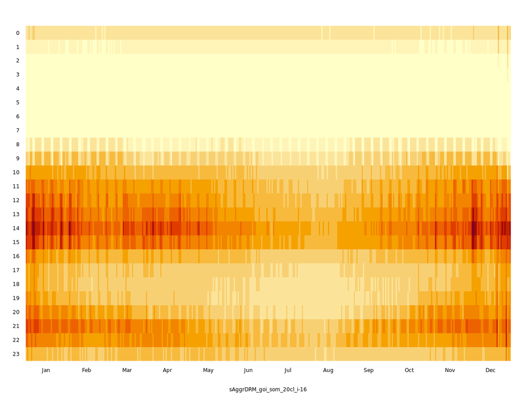

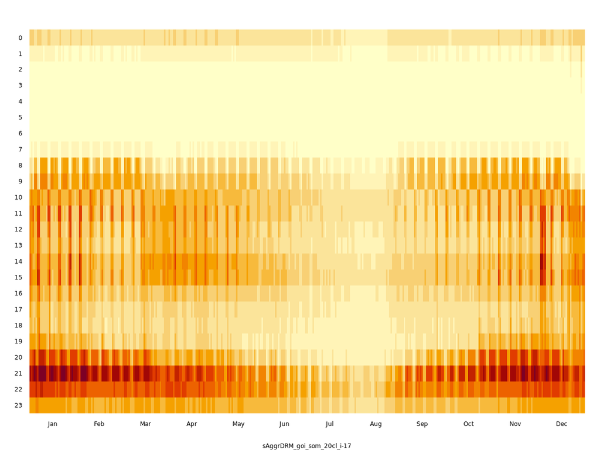

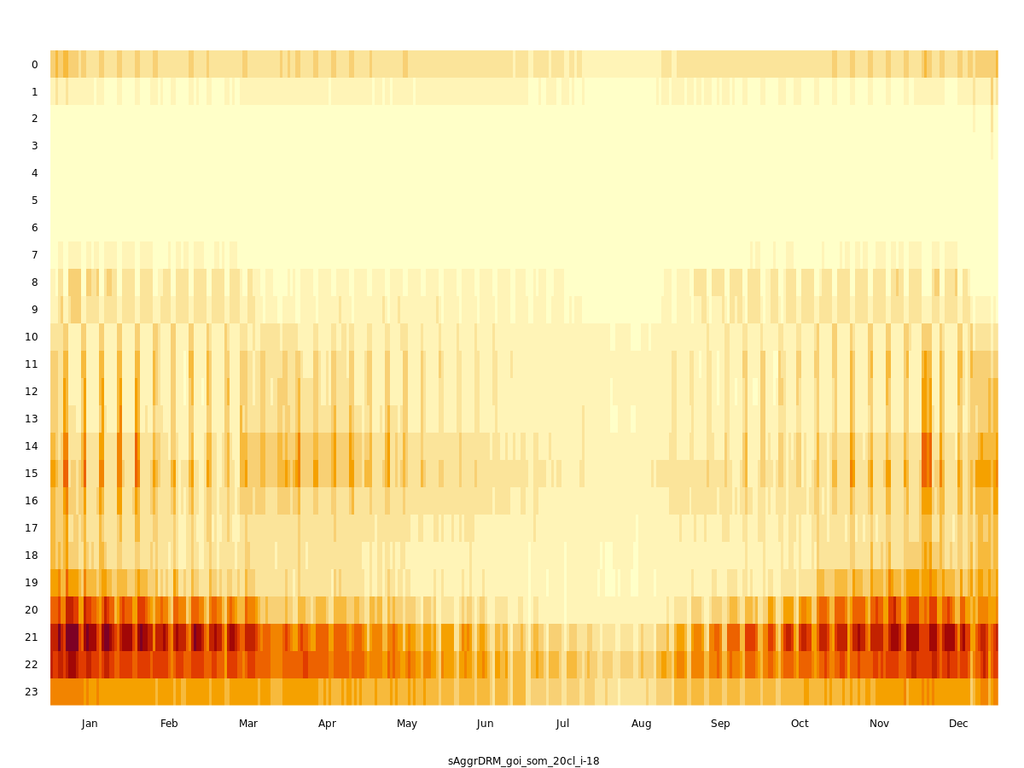

sAggrDRM > goi > som > #13

486 TS (3.2%)

sAggrDRM > goi > som > #14

224 TS (1.5%)

sAggrDRM > goi > som > #15

930 TS (6.1%)

sAggrDRM > goi > som > #16

1390 TS (9.1%)

sAggrDRM > goi > som > #17

1874 TS (12.3%)

sAggrDRM > goi > som > #18

872 TS (5.7%)

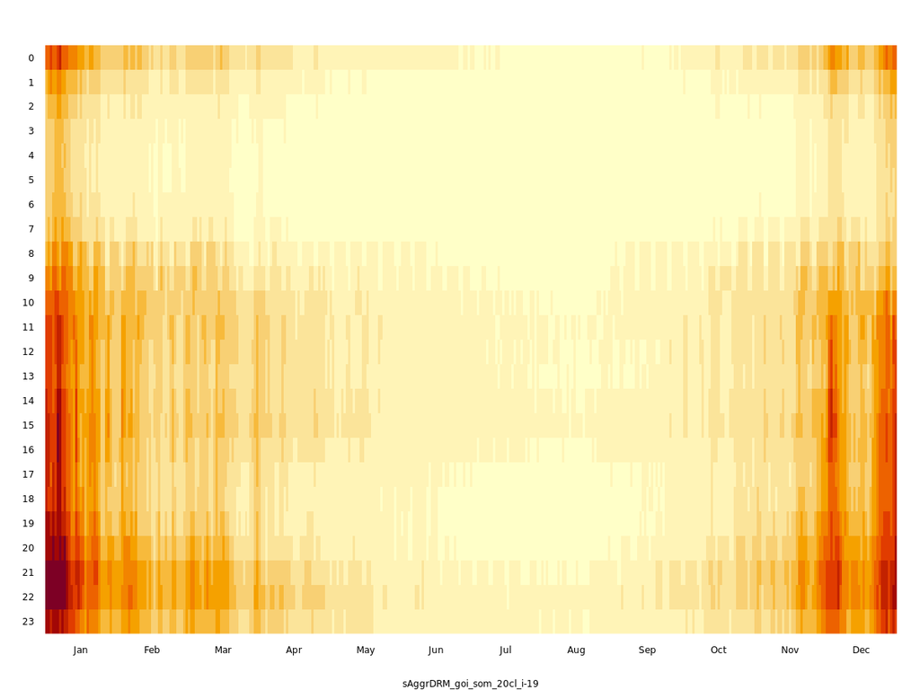

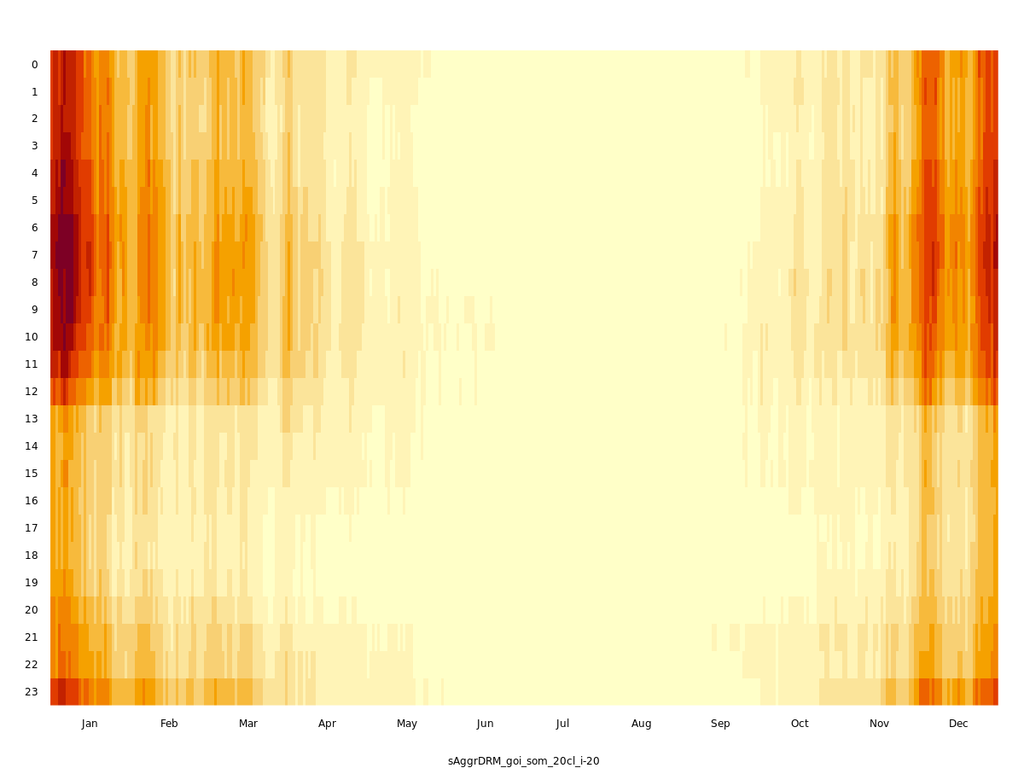

sAggrDRM > goi > som > #19

747 TS (4.9%)

sAggrDRM > goi > som > #20

269 TS (1.8%)